# Data Camp Python Notes

**Average Daily Rides by Month - Chicago Train (CTA) 2015-2016**:

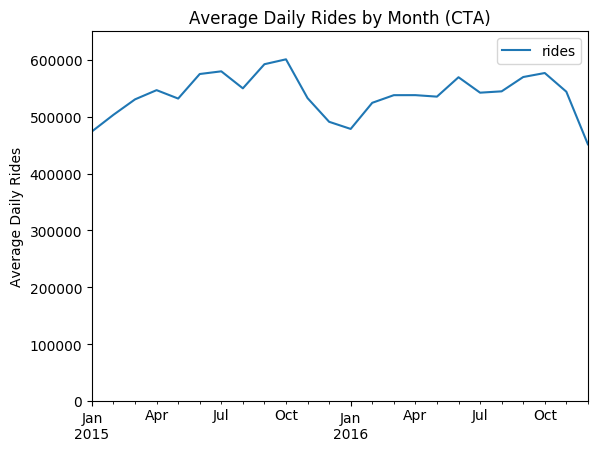

**Average Daily Rides by Month - 2015 vs 2016**:

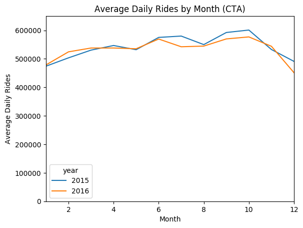

**Average Daily Rides by Day Type - (CTA 2015-2016)**:

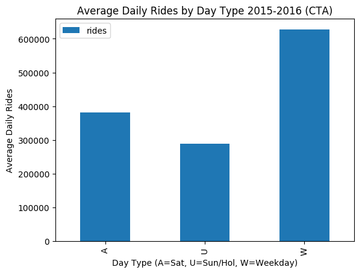

**Average Daily Rides by Station - (CTA 2015-2016)**:

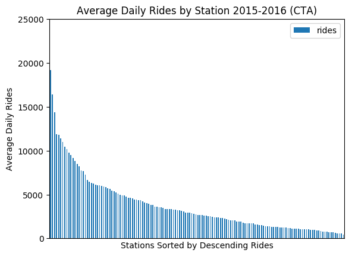

**Average Daily Rides by Station and Day Type - (CTA 2015-2016)**:

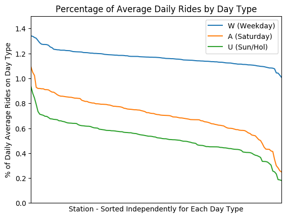

**Consistency of Average Rides by Station and Day Type - (CTA 2015-2016)**:

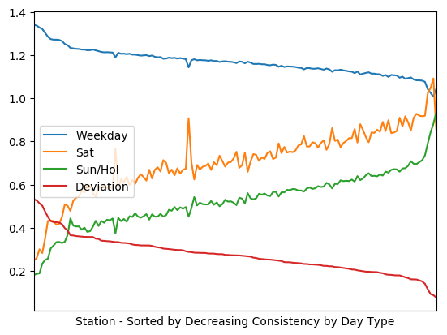

**Seasonality of Average Rides by Station - (CTA 2015-2016)**:

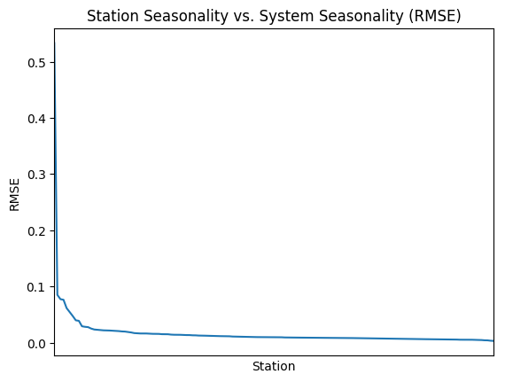

**Stations with Greatest Seasonality of Average Rides - (CTA 2015-2016)**:

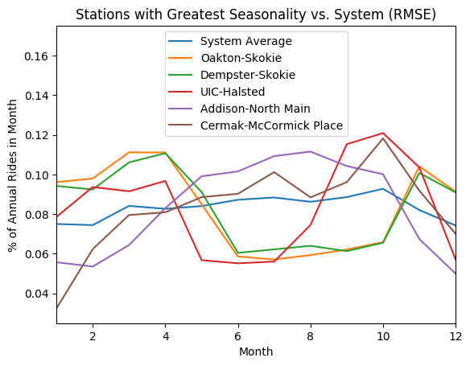

**Average Daily Rides by Day of Week - (CTA 2015-2016)**:

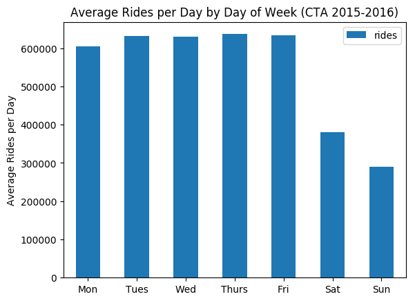

**Consistency by Station of Average Daily Rides by Day of Week - (CTA 2015-2016)**:

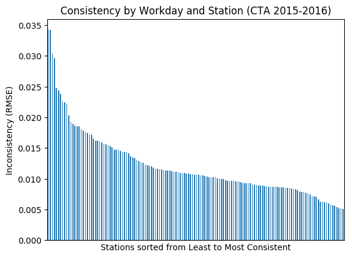

**Stations with Greatest Difference from System Average Rides by Day of Week - (CTA 2015-2016)**:

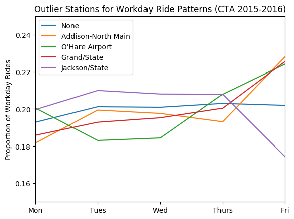

Additional Exploration - Chicago Crimes

Some additional experimentation with the Chicago Crime data, including:

- Trend in total crime by day and month
- Total crime by type and district
- Clearance rate by crime type
- Cleared crimes by crime type

Example code includes:

```python
myPath = "./PythonInputFiles/"



# Chicago Open Data crime database - filtered for 2015 only and districts 001, 016, and 019
# https://data.cityofchicago.org/Public-Safety/Crimes-2015/vwwp-7yr9
# File is in myPath + "Chicago_Crime_2015_001_016_019.csv"
import pandas as pd
from datetime import datetime
import matplotlib.pyplot as plt
import numpy as np


rawCrime = pd.read_csv(myPath + "Chicago_Crime_2015_001_016_019.csv")
filtCrime = rawCrime[["Date", "Block", "Primary Type", "Description", "Location Description", "Arrest", "District", "Beat", "Ward", "Community Area"]]
filtCrime["convDate"] = [datetime.strptime(x.split()[0], "%m/%d/%Y") for x in filtCrime["Date"]]


# Total crime by day and month
dateCrime = filtCrime[["convDate", "Block"]].groupby("convDate").count()
dateCrime.plot()
plt.ylim([0, 10 * round(max(dateCrime["Block"]) / 10, 0) + 10])
plt.xlabel("")
plt.title("Chicago Crimes by Day in 2015 \n(Districts 001, 016, 019)")
# plt.show()
plt.savefig("_dummyPy104.png", bbox_inches="tight")
plt.clf()


dateCrime.resample("M").sum().plot(kind="bar")
plt.xticks(np.arange(12), ["Jan", "Feb", "Mar", "Apr", "May", "Jun", "Jul", "Aug", "Sep", "Oct", "Nov", "Dec"], rotation=0)
plt.xlabel("")
plt.title("Chicago Crimes by Month in 2015 \n(Districts 001, 016, 019)")
# plt.show()
plt.savefig("_dummyPy105.png", bbox_inches="tight")
plt.clf()


# Total crime by type and District
typeCrime = filtCrime.pivot_table(index="Primary Type", columns="District", values="Block", aggfunc=len).fillna(0)
typeCrime["Total"] = typeCrime.apply(sum, axis=1)

print(typeCrime.sort_values("Total", ascending=False).iloc[0:20, :])


# Clearance Rate by Crime Type
arrestCrime = filtCrime[["Primary Type", "Arrest"]].pivot_table(index="Primary Type", columns="Arrest", aggfunc=len).fillna(0)
arrestCrime["Total"] = arrestCrime.apply(sum, axis=1)
arrestCrime["Clear"] = arrestCrime[True] / arrestCrime["Total"]
arrestCrime = arrestCrime.sort_values("Total", ascending=False)

print(arrestCrime.iloc[0:20, :])
nPlot = 12

fig, ax1 = plt.subplots()

(arrestCrime["Total"][0:nPlot]/1000).plot(kind="bar")
plt.title("Chicago Crimes and Clearance Rate in 2015 \n(Districts 001, 016, 019)")
plt.xlabel("Crime Type")
xTickNewLine = [x.capitalize().replace(" ", "\n") for x in arrestCrime.index]
plt.xticks(np.arange(nPlot), xTickNewLine[0:nPlot], fontsize=9, rotation=90)

ax1.set_ylabel("Total Crimes (000)", color="b")
ax1.tick_params("y", colors="b")

ax2 = plt.twinx()
ax2.plot(list(arrestCrime["Clear"][0:nPlot]), "r-")
ax2.set_ylabel("Clearance Rate", color="r")
ax2.tick_params("y", colors="r")

plt.tight_layout()
# plt.show()
plt.savefig("_dummyPy106.png", bbox_inches="tight")
plt.clf()


# Chicago Crimes Cleared
nPlot = 12
(arrestCrime.sort_values(True, ascending=False)[True][0:nPlot]/1000).plot(kind="bar")
plt.title("Chicago Crimes Cleared in 2015 \n(Districts 001, 016, 019)")
plt.xlabel("Crime Type")
xTickNewLine = [x.capitalize().replace(" ", "\n") for x in arrestCrime.sort_values(True, ascending=False).index]
plt.xticks(np.arange(nPlot), xTickNewLine[0:nPlot], fontsize=9, rotation=90)
plt.ylabel("Total Crimes Cleared (000)")
plt.tight_layout()
# plt.show()
plt.savefig("_dummyPy107.png", bbox_inches="tight")
plt.clf()


# Total crime by location description
locCrime = filtCrime["Location Description"].value_counts()
print(locCrime[0:20])
print(locCrime[0:20].cumsum() / sum(locCrime))
nPlot=15
(locCrime[0:nPlot].cumsum() / sum(locCrime)).plot(kind="bar")
plt.ylim([0, 1])
plt.ylabel("Cumulative percentage of locations")
plt.xlabel("")
plt.title("ECDF for crime locations - Chicago 2015\n(Districts 001, 016, 019)")
xTickNewLine = [x[0:20].capitalize().replace(" ", "\n") for x in locCrime.index]
plt.xticks(np.arange(nPlot), xTickNewLine[0:nPlot], fontsize=8, rotation=90)
plt.tight_layout()
# plt.show()
plt.savefig("_dummyPy108.png", bbox_inches="tight")
plt.clf()


# Total crime by location description and district
locDistCrime = filtCrime[["Location Description", "District"]].pivot_table(index="Location Description", columns="District", aggfunc=len).fillna(0)
locDistCrime["Total"] = locDistCrime.apply(sum, axis=1)
locDistCrime = locDistCrime.sort_values("Total", ascending=False)

nPlot = 15

fig, ax1 = plt.subplots()

(locDistCrime["Total"][0:nPlot]).plot(kind="bar", color="b", alpha=0.5)
plt.title("Chicago Crime Locations by District in 2015 \n(Districts 001, 016, 019)")
plt.xlabel("Location Description")
xTickNewLine = [x[0:20].capitalize().replace(" ", "\n") for x in locDistCrime.index]
plt.xticks(np.arange(nPlot), xTickNewLine[0:nPlot], fontsize=8, rotation=90)

ax1.set_ylabel("Total Crimes", color="b")
ax1.tick_params("y", colors="b")

ax2 = plt.twinx()
ax2.plot(list((locDistCrime[1]/locDistCrime["Total"])[0:nPlot]), "r-")
ax2.plot(list((locDistCrime[16]/locDistCrime["Total"])[0:nPlot]), "g-")
ax2.plot(list((locDistCrime[19]/locDistCrime["Total"])[0:nPlot]), "y-")
ax2.set_ylim([0, 1])
ax2.set_ylabel("Proportion by District")

plt.legend(["001", "016", "019"])
plt.tight_layout()
# plt.show()
plt.savefig("_dummyPy109.png", bbox_inches="tight")
plt.clf()
```

```
## -c:17: SettingWithCopyWarning:
## A value is trying to be set on a copy of a slice from a DataFrame.
## Try using .loc[row_indexer,col_indexer] = value instead
##
## See the caveats in the documentation: http://pandas.pydata.org/pandas-docs/stable/indexing.html#indexing-view-versus-copy
## District                               1      16      19    Total
## Primary Type
## THEFT                             5651.0  2192.0  4177.0  12020.0
## BATTERY                           1313.0  1406.0  1600.0   4319.0
## DECEPTIVE PRACTICE                1431.0   771.0  1069.0   3271.0
## CRIMINAL DAMAGE                    732.0  1201.0  1169.0   3102.0
## OTHER OFFENSE                      471.0   842.0   435.0   1748.0
## ASSAULT                            530.0   528.0   490.0   1548.0
## CRIMINAL TRESPASS                  596.0   402.0   398.0   1396.0
## BURGLARY                           176.0   597.0   597.0   1370.0
## NARCOTICS                          219.0   528.0   404.0   1151.0
## MOTOR VEHICLE THEFT                196.0   344.0   416.0    956.0
## ROBBERY                            319.0   159.0   371.0    849.0
## PUBLIC PEACE VIOLATION              99.0    92.0    76.0    267.0
## OFFENSE INVOLVING CHILDREN          47.0    88.0    64.0    199.0
## CRIM SEXUAL ASSAULT                 28.0    40.0    86.0    154.0
## SEX OFFENSE                         49.0    44.0    49.0    142.0
## WEAPONS VIOLATION                   23.0    48.0    33.0    104.0
## INTERFERENCE WITH PUBLIC OFFICER    14.0    20.0    26.0     60.0
## LIQUOR LAW VIOLATION                12.0    12.0    26.0     50.0
## PROSTITUTION                        24.0     7.0     3.0     34.0
## ARSON                                7.0     8.0    19.0     34.0
## Arrest                              False    True    Total     Clear
## Primary Type
## THEFT                             10424.0  1596.0  12020.0  0.132779
## BATTERY                            3119.0  1200.0   4319.0  0.277842
## DECEPTIVE PRACTICE                 3070.0   201.0   3271.0  0.061449
## CRIMINAL DAMAGE                    2909.0   193.0   3102.0  0.062218
## OTHER OFFENSE                      1551.0   197.0   1748.0  0.112700
## ASSAULT                            1152.0   396.0   1548.0  0.255814
## CRIMINAL TRESPASS                   339.0  1057.0   1396.0  0.757163
## BURGLARY                           1281.0    89.0   1370.0  0.064964
## NARCOTICS                             2.0  1149.0   1151.0  0.998262
## MOTOR VEHICLE THEFT                 892.0    64.0    956.0  0.066946
## ROBBERY                             737.0   112.0    849.0  0.131920
```

[output cut: 36 more lines]

```
## PARKING LOT/GARAGE(NON.RESID.)    0.597630
## DEPARTMENT STORE                  0.634189
## SMALL RETAIL STORE                0.669470
## RESIDENCE-GARAGE                  0.691405
## GROCERY FOOD STORE                0.708771
## RESIDENCE PORCH/HALLWAY           0.724949
## PARK PROPERTY                     0.740944
## HOTEL/MOTEL                       0.755629
## ALLEY                             0.770100
## BAR OR TAVERN                     0.784541
## RESIDENTIAL YARD (FRONT/BACK)     0.796819
## VEHICLE NON-COMMERCIAL            0.808031
## COMMERCIAL / BUSINESS OFFICE      0.819243
## SCHOOL, PUBLIC, BUILDING          0.829967
## Name: Location Description, dtype: float64
```

**Crimes by Day (Chicago 2015 - Districts 001, 016, 019)**:

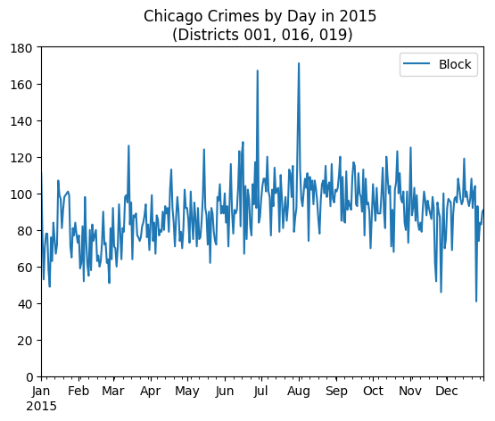

**Crimes by Month (Chicago 2015 - Districts 001, 016, 019)**:

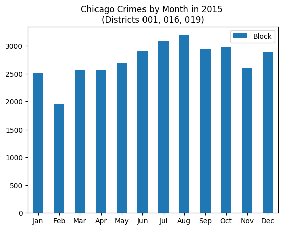

**% Crimes Cleared by Crime Type (Chicago 2015 - Districts 001, 016, 019)**:

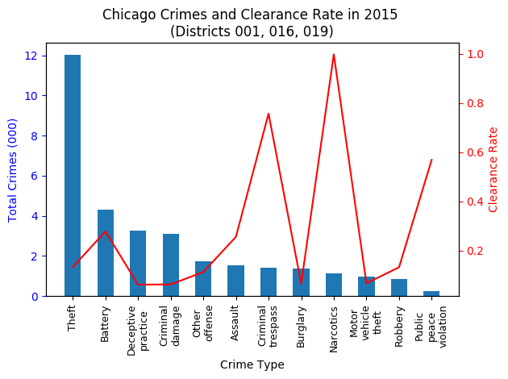

**Total # Crimes Cleared by Crime Type (Chicago 2015 - Districts 001, 016, 019)**:

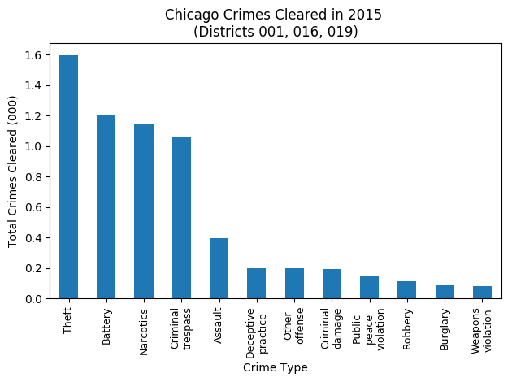

**ECDF for Location Descriptions (Chicago 2015 - Districts 001, 016, 019)**:

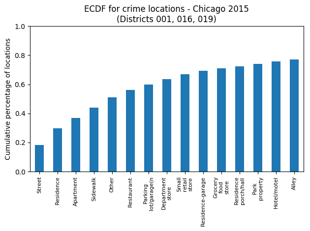

**Location Descriptions by District (Chicago 2015 - Districts 001, 016, 019)**:

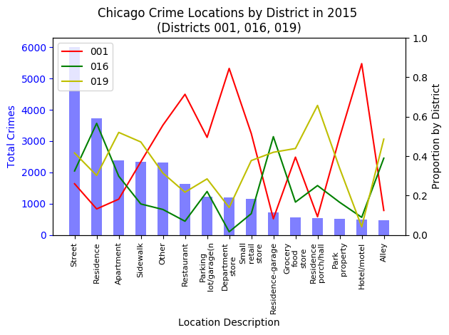

## Python Visualization

### *Introduction to Data Visualization with Python*

Chapter 1 - Data Ingestion and Inspection

Plotting multiple graphs - suppose that you have measurements time, Temperature, and DewPoint:

- With “import matplotlib.pyplot as plt”, then plt.plot() works on numpy arrays, lists, pandas DataSeries
  - plt.plot(time, Temperature, “red”)
  - plt.plot(time, DewPoint, “red”) # overlays the curve on the same axes
  - plt.xlabel(“Date”) ; plt.title(“Temperature & Dew Point”)
  - plt.show() # shows the figure on screen
- The plt.axes([]) commands will both establish axes and ask that the next curve(s) be drawn on those axes
  - plt.axes([0.05, 0.05, 0.425, 0.9]) # sets up the axes for a first plot
  - plt. # things to be drawn on this axis
  - plt.axes([0.525, 0.05, 0.425, 0.9]) # sets up the axes for a second plot
  - plt. # things to be drawn on this axis
  - plt.show() # shows the figure on the screen
- The commands inside plt.axes([x_lo, y_lo, width, height]) will “sometimes require some trial and error to get right”
  - The x_lo of 0.05 means 5% of the way to the right of the “full screen” while the width of 0.425 means 42.5% of the “full screen”, so draw from 5% to 47.5% of “full-screen width”
- Conversely, the suplot() command will create multiple axes without the need for this type of customization
  - plt.subplot(nrows, ncols, thisSubPlot) # sets up a grid of nrows x ncols; activates thisSubPlot which will be active until next call of plt.subplot() - across rows, then down columns, indexed from 1 (not 0)
  - plt.tight_layout() # helps avoid tick overlap and excessive white-space

Customizing axes - making the plots less messy and more appealing:

- The plt.axis([xmin, xmax, ymin, ymax]) will control the zoom of the x/y components of the axis
  - Alternately, plt.xlim([xmin, xmax]) will control just the x-axis limits
  - Alternately, plt.ylim([ymin, ymax]) will control just the y-axis limits
  - Arguments can be passed as tuples or as lists - xlim((-2, 3)) and xlim([-2, 3]) do the same thing
  - Interestingly, if just the xlim() is provided, then the ylim() will default to what is best for the full plot (including things not in xlim), so it may nonetheless be necessary to provide a ylim()
- There are other commands available to plt.axis(), including
  - axis(“off”) - turns off axis lines, labels
  - axis(“equal”) - equal scaling on x, y axes
  - axis(“square”) - forces square plot
  - axis(“tight”) - sets xlim() and ylim() to show all the data

Legends, annotations, and styles:

- Legends - provide labels for overlaid points and curves
  - Can be passed as part of the plotting command, such as plt.scatter(x, y, marker=“o”, color=“red”, label=“setosa”)
  - The legend is then created using plt.legend(loc=“upper right”) # loc can be set to other areas to move the legend - default is “best”
- Annotations - text labels, including optionally arrows from the text to other components of the graph
  - plt.annotate(“myText”, xy=(x, y)) # will place “myText” at location x, y
  - Additional options are xytext (coordinates of label) or arrowprops (controls drawing of arrow)
  - plt.annotate(“myText”, xy=(x, y), xytext=(x1, y1), arrowprops={“color”:“red”}) # will place “myText” at location x1, y1 and draw a red arrow to point x, y
  - Often requires some experimentation to get to a visually pleasing plot
- Styles - controlled by the default style sheets in Matplotlib
  - Can switch between styles using plt.style.use() # ggplot is an option, so plt.style.use(“ggplot”) ; fivethirtyeight is an option, so plt.style.use(“fivethirtyeight”)
  - Can see what styles are available with plt.style.available

Example code includes:

```python
year = [1970, 1971, 1972, 1973, 1974, 1975, 1976, 1977, 1978, 1979, 1980, 1981, 1982, 1983, 1984, 1985, 1986, 1987, 1988, 1989, 1990, 1991, 1992, 1993, 1994, 1995, 1996, 1997, 1998, 1999, 2000, 2001, 2002, 2003, 2004, 2005, 2006, 2007, 2008, 2009, 2010, 2011]
physical_sciences = [13.800000000000001, 14.9, 14.800000000000001, 16.5, 18.199999999999999, 19.100000000000001, 20.0, 21.300000000000001, 22.5, 23.699999999999999, 24.600000000000001, 25.699999999999999, 27.300000000000001, 27.600000000000001, 28.0, 27.5, 28.399999999999999, 30.399999999999999, 29.699999999999999, 31.300000000000001, 31.600000000000001, 32.600000000000001, 32.600000000000001, 33.600000000000001, 34.799999999999997, 35.899999999999999, 37.299999999999997, 38.299999999999997, 39.700000000000003, 40.200000000000003, 41.0, 42.200000000000003, 41.100000000000001, 41.700000000000003, 42.100000000000001, 41.600000000000001, 40.799999999999997, 40.700000000000003, 40.700000000000003, 40.700000000000003, 40.200000000000003, 40.100000000000001]
computer_science = [13.6, 13.6, 14.9, 16.399999999999999, 18.899999999999999, 19.800000000000001, 23.899999999999999, 25.699999999999999, 28.100000000000001, 30.199999999999999, 32.5, 34.799999999999997, 36.299999999999997, 37.100000000000001, 36.799999999999997, 35.700000000000003, 34.700000000000003, 32.399999999999999, 30.800000000000001, 29.899999999999999, 29.399999999999999, 28.699999999999999, 28.199999999999999, 28.5, 28.5, 27.5, 27.100000000000001, 26.800000000000001, 27.0, 28.100000000000001, 27.699999999999999, 27.600000000000001, 27.0, 25.100000000000001, 22.199999999999999, 20.600000000000001, 18.600000000000001, 17.600000000000001, 17.800000000000001, 18.100000000000001, 17.600000000000001, 18.199999999999999]

# Import matplotlib.pyplot
import matplotlib.pyplot as plt

# Plot in blue the % of degrees awarded to women in the Physical Sciences
plt.plot(year, physical_sciences, color='blue')

# Plot in red the % of degrees awarded to women in Computer Science
plt.plot(year, computer_science, color='red')

# Display the plot
# plt.show()
plt.savefig("_dummyPy110.png", bbox_inches="tight")
plt.clf()


# Create plot axes for the first line plot
plt.axes([0.05, 0.05, 0.425, 0.9])

# Plot in blue the % of degrees awarded to women in the Physical Sciences
plt.plot(year, physical_sciences, color='blue')

# Create plot axes for the second line plot
plt.axes([0.525, 0.05, 0.425, 0.9])

# Plot in red the % of degrees awarded to women in Computer Science
plt.plot(year, computer_science, color='red')

# Display the plot
# plt.show()
plt.savefig("_dummyPy111.png", bbox_inches="tight")
plt.clf()


# Create a figure with 1x2 subplot and make the left subplot active
plt.subplot(1, 2, 1)

# Plot in blue the % of degrees awarded to women in the Physical Sciences
plt.plot(year, physical_sciences, color='blue')
plt.title('Physical Sciences')

# Make the right subplot active in the current 1x2 subplot grid
plt.subplot(1, 2, 2)

# Plot in red the % of degrees awarded to women in Computer Science
plt.plot(year, computer_science, color='red')
plt.title('Computer Science')

# Use plt.tight_layout() to improve the spacing between subplots
plt.tight_layout()
# plt.show()
plt.savefig("_dummyPy112.png", bbox_inches="tight")
plt.clf()


health = [77.099999999999994, 75.5, 76.900000000000006, 77.400000000000006, 77.900000000000006, 78.900000000000006, 79.200000000000003, 80.5, 81.900000000000006, 82.299999999999997, 83.5, 84.099999999999994, 84.400000000000006, 84.599999999999994, 85.099999999999994, 85.299999999999997, 85.700000000000003, 85.5, 85.200000000000003, 84.599999999999994, 83.900000000000006, 83.5, 83.0, 82.400000000000006, 81.799999999999997, 81.5, 81.299999999999997, 81.900000000000006, 82.099999999999994, 83.5, 83.5, 85.099999999999994, 85.799999999999997, 86.5, 86.5, 86.0, 85.900000000000006, 85.400000000000006, 85.200000000000003, 85.099999999999994, 85.0, 84.799999999999997]
education = [74.535327580000001, 74.149203689999993, 73.554519959999993, 73.501814429999996, 73.336811429999997, 72.801854480000003, 72.166524710000004, 72.456394810000006, 73.192821339999995, 73.821142339999994, 74.981031520000002, 75.845123450000003, 75.843649139999997, 75.950601230000004, 75.869116009999999, 75.923439709999997, 76.143015160000004, 76.963091680000005, 77.627661770000003, 78.111918720000006, 78.866858590000007, 78.991245969999994, 78.435181909999997, 77.267311989999996, 75.814932639999995, 75.125256210000003, 75.035199210000002, 75.163701299999985, 75.486160269999999, 75.838162060000002, 76.692142840000002, 77.375229309999995, 78.644243939999996, 78.544948149999996, 78.65074774, 79.067121729999997, 78.686305509999997, 78.72141311, 79.196326740000003, 79.532908700000007, 79.618624510000004, 79.432811839999999]

# Create a figure with 2x2 subplot layout and make the top left subplot active
plt.subplot(2, 2, 1)

# Plot in blue the % of degrees awarded to women in the Physical Sciences
plt.plot(year, physical_sciences, color='blue')
plt.title('Physical Sciences')

# Make the top right subplot active in the current 2x2 subplot grid
plt.subplot(2, 2, 2)

# Plot in red the % of degrees awarded to women in Computer Science
plt.plot(year, computer_science, color='red')
plt.title('Computer Science')

# Make the bottom left subplot active in the current 2x2 subplot grid
plt.subplot(2, 2, 3)

# Plot in green the % of degrees awarded to women in Health Professions
plt.plot(year, health, color='green')
plt.title('Health Professions')

# Make the bottom right subplot active in the current 2x2 subplot grid
plt.subplot(2, 2, 4)

# Plot in yellow the % of degrees awarded to women in Education
plt.plot(year, education, color='yellow')
plt.title('Education')

# Improve the spacing between subplots and display them
plt.tight_layout()
# plt.show()
plt.savefig("_dummyPy113.png", bbox_inches="tight")
plt.clf()


# Plot the % of degrees awarded to women in Computer Science and the Physical Sciences
plt.plot(year,computer_science, color='red')
plt.plot(year, physical_sciences, color='blue')

# Add the axis labels
plt.xlabel('Year')
plt.ylabel('Degrees awarded to women (%)')

# Set the x-axis range
plt.xlim(1990, 2010)

# Set the y-axis range
plt.ylim(0, 50)

# Add a title and display the plot
plt.title('Degrees awarded to women (1990-2010)\nComputer Science (red)\nPhysical Sciences (blue)')
# plt.show()
plt.savefig("_dummyPy114.png", bbox_inches="tight")
plt.clf()


# Save the image as 'xlim_and_ylim.png'
# plt.savefig("xlim_and_ylim.png")


# Plot in blue the % of degrees awarded to women in Computer Science
plt.plot(year,computer_science, color='blue')

# Plot in red the % of degrees awarded to women in the Physical Sciences
plt.plot(year, physical_sciences,color='red')

# Set the x-axis and y-axis limits
plt.axis([1990, 2010, 0, 50])

# Show the figure
# plt.show()
plt.savefig("_dummyPy115.png", bbox_inches="tight")
plt.clf()


# Save the figure as 'axis_limits.png'
# plt.savefig("axis_limits.png")


# Specify the label 'Computer Science'
plt.plot(year, computer_science, color='red', label='Computer Science')

# Specify the label 'Physical Sciences'
plt.plot(year, physical_sciences, color='blue', label='Physical Sciences')

# Add a legend at the lower center
plt.legend(loc="lower center")

# Add axis labels and title
plt.xlabel('Year')
plt.ylabel('Enrollment (%)')
plt.title('Undergraduate enrollment of women')
# plt.show()
plt.savefig("_dummyPy116.png", bbox_inches="tight")
plt.clf()


# Plot with legend as before
plt.plot(year, computer_science, color='red', label='Computer Science')
plt.plot(year, physical_sciences, color='blue', label='Physical Sciences')
plt.legend(loc='bottom right')

# Compute the maximum enrollment of women in Computer Science: cs_max
# cs_max = computer_science.max()
cs_max = max(computer_science)

# Calculate the year in which there was maximum enrollment of women in Computer Science: yr_max
#yr_max = year[computer_science.argmax()]
yr_max = year[computer_science.index(cs_max)]

# Add a black arrow annotation
plt.annotate("Maximum", xy=(yr_max, cs_max), xytext=(yr_max + 5, cs_max + 5), arrowprops={"facecolor":'black'})

# Add axis labels and title
plt.xlabel('Year')
plt.ylabel('Enrollment (%)')
plt.title('Undergraduate enrollment of women')
# plt.show()
plt.savefig("_dummyPy117.png", bbox_inches="tight")
plt.clf()


# Import matplotlib.pyplot
import matplotlib.pyplot as plt

# Set the style to 'ggplot'
plt.style.use("ggplot")

# Create a figure with 2x2 subplot layout
plt.subplot(2, 2, 1)

# Plot the enrollment % of women in the Physical Sciences
plt.plot(year, physical_sciences, color='blue')
plt.title('Physical Sciences')

# Plot the enrollment % of women in Computer Science
plt.subplot(2, 2, 2)
plt.plot(year, computer_science, color='red')
plt.title('Computer Science')

# Add annotation
cs_max = max(computer_science)
yr_max = year[computer_science.index(cs_max)]
plt.annotate('Maximum', xy=(yr_max, cs_max), xytext=(yr_max-1, cs_max-10), arrowprops=dict(facecolor='black'))

# Plot the enrollmment % of women in Health professions
plt.subplot(2, 2, 3)
plt.plot(year, health, color='green')
plt.title('Health Professions')

# Plot the enrollment % of women in Education
plt.subplot(2, 2, 4)
plt.plot(year, education, color='yellow')
plt.title('Education')

# Improve spacing between subplots and display them
plt.tight_layout()
# plt.show()
plt.savefig("_dummyPy118.png", bbox_inches="tight")
plt.clf()
```

**Example #1: Unlabelled Plot on Single Set of Axes**:

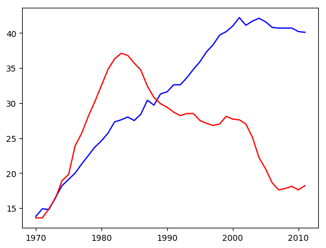

**Example #2: Subplots on Separate Axes**:

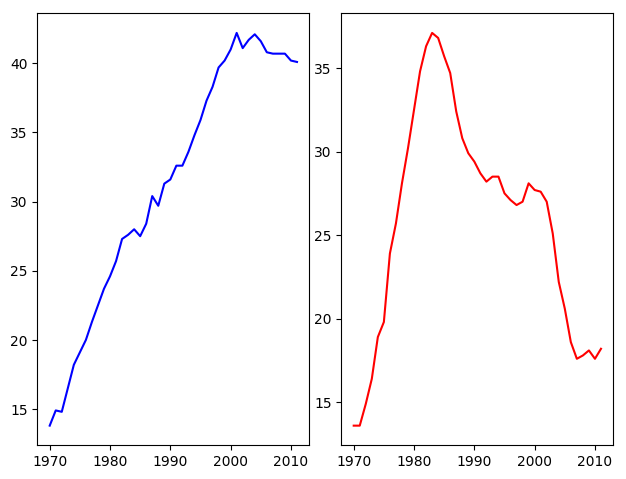

**Example #3: Subplots on Separate Axes with Titles**:

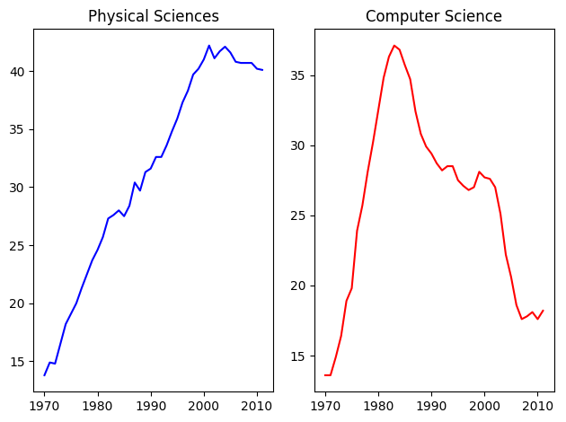

**Example #4: Subplots on Separate Axes with Titles**:

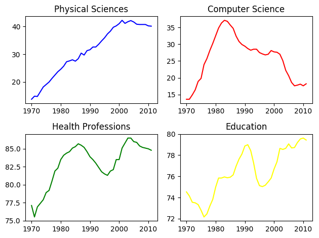

**Example #5: Title and Axis Labels for Two Plots on a Single Set of Axes**:

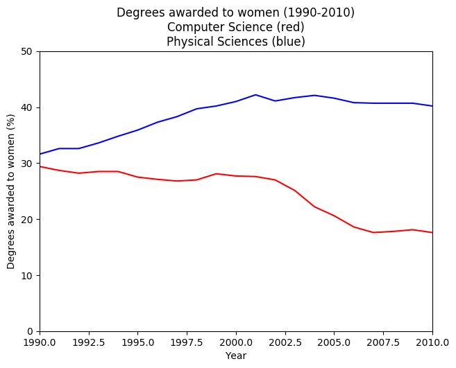

**Example #6: Title, Axis Labels, and Legend for Two Plots on a Single Set of Axes**:

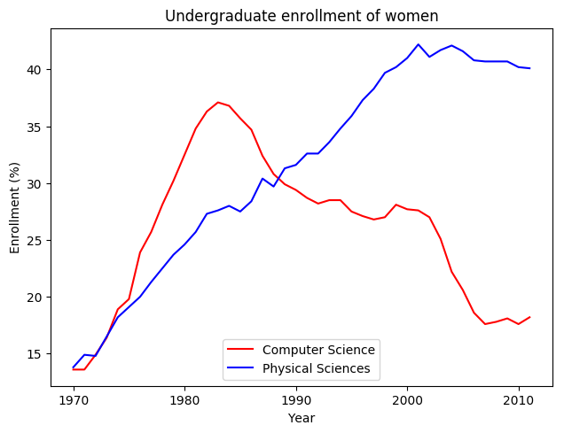

**Example #7: Annotation with Arrow**:

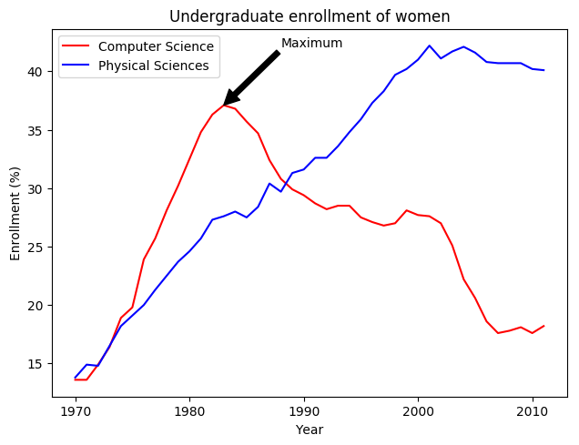

**Example #8: Subplots in ggplot2 Format with One Subplot Annotated**:

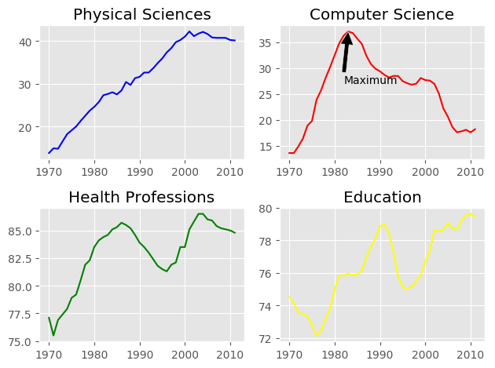

Chapter 2 - Plotting 2D Arrays (Raster Data or Bivariate Function Data)

Working with 2D Arrays - reminders about NumPy arrays:

- NumPy arrays are homogenous in type, allowing for calculations all at once across the entire array
  - A[index] will grab an item from a 1D array
  - A[index0, index1] will grab an item from a 2D array
  - Slicing can be done with start:stop:stride # runs from start to stop-1, with stride being the step
- All images are 2D arrays of intensity - single intensity for gray-scale, multiple intensities (RGB) for color
  - import numpy as np
  - u = np.linspace(-2, 2, 3) # 3 total elements equally spaced from -2 to 2, so [-2, 0, 2]
  - v = np.linspace(-1, 1, 5) # 5 total elements equally spaced from -1 to 1, so [-1, -0.5, 0, 0.5, 1]
  - X, Y = np.meshgrid(u, v) # replicates the 1D grids along different axes, more or less making a 2D array – X and Y are both 5 x 3 with every row of X being u and every column of Y being v
  - Z = X**2/25 + Y**2/4 ; print(“Z:”, Z)
  - plt.set_cmap(“gray”) # sets the color map to grey-scale
  - plt.pcolor(Z) # described later in the chapter, stands for “pseudo-color”
  - plt.show()
- Orientations of 2D arrays and images - arrays are written differently by hand than plotted by computer
  - Plotting runs left-to-right but also bottom-to-top, so the first element of the array (upper-left) will appear in the bottom-left of the image

Visualizing bivariate functions - including the “pseudo-color” (plt.pcolor()) calls:

- Pseudo-color plot are multi-colored and have spill-over (white space on the sides) and have axes that are integers rather than coordinates
  - Can see the colorbar using plt.colorbar() ; this will display the mapping of colors to values in the plot
  - Using the cmap= option within plt.pcolor() allows for over-riding the defaults ; for example, plt.pcolor(Z, cmap=“gray”)
- The issues with spill-over can be addressed using plt.axis(“tight”)
- The issues with the axes as integers can be addressed by calling plt.pcolor(X, Y, Z) where X and Y are the associated elements of the mesh-grid and Z is the value to be plotted
- By design, plt.pcolor() will make “blocky” images, which may be OK depending on the underlying data / issue explored
  - The alternative is to use plt.contour(Z, n), which will make “n” smooth-curves of constant value
  - The other alternative is plt.contourf(Z, n) which will make “n” filled contours of constant value

Visualizing bivariate distributions - distributions of 2D points:

- Example of 2D points given as two 1D arrays x and y (from automobiles data - Weight vs Acceleration), goal is to generate a histogram from x and y
  - For 1D data, the histogram can show the counts of values by bin, accessible using plt.hist()
- For 2D data, there are more options for binning shapes (as opposed to 1D where they will be line segments)
  - Rectangles are the most obvious strategy - plt.hist2d(x, y, bins=(xbins, ybins))
  - Hexagons are another strategy - plt.hexbin(x, y, gridsize=(xSize, ySize)

Working with images (matrices of intensity values):

- Color images are frequently stored as 3-D arrays, one 2-D array for each of Red, Green, Blue
  - The values may range as floats from 0-1 reflecting intensity (0=0%, 1=100%)
  - The values may range as integers from 0-255 reflecting intensity (0=0%, 255=100%)
- Reading and displaying images using matplotlib.pyplot as plt
  - img = plt.imread(“myImageFile”)
  - plt.imshow(img)
  - plt.axis(“off”)
  - plt.show()
- Creating a grey-scale image can be as easy as averaging the intensity across the third dimension (axis=2)
  - collapsed = img.mean(axis=2)
- Default assumption for plotting is that aspect-ratio is 1 (pixel means the same thing in every direction)
  - Can over-ride, such as plt.imshow(img, aspect=2.0)
  - Alternately, can over-ride such as plt.imshow(img, extent=(0, 640, 0, 480)) # value in extent are left, right, bottom, top

Example code includes:

```python
myPath = "./PythonInputFiles/"



# Import numpy and matplotlib.pyplot
import numpy as np
import matplotlib.pyplot as plt

# Generate two 1-D arrays: u, v
u = np.linspace(-2, 2, 41)
v = np.linspace(-1, 1, 21)

# Generate 2-D arrays from u and v: X, Y
X,Y = np.meshgrid(u, v)

# Compute Z based on X and Y
Z = np.sin(3*np.sqrt(X**2 + Y**2))

# Display the resulting image with pcolor()
plt.pcolor(Z)
# plt.show()

# Save the figure to 'sine_mesh.png'
# plt.savefig("sine_mesh.png")


u = np.linspace(-2, 2, 101)
v = np.linspace(0, 2, 51)
X,Y = np.meshgrid(u, v)
Z = X**2/8 + Y**2/8


plt.set_cmap("viridis")  # bring back to what it looks like DataCamp may be using

# Generate a default contour map of the array Z
plt.subplot(2,2,1)
plt.contour(X, Y, Z)

# Generate a contour map with 20 contours
plt.subplot(2,2,2)
plt.contour(X, Y, Z, 20)

# Generate a default filled contour map of the array Z
plt.subplot(2,2,3)
plt.contourf(X, Y, Z)

# Generate a default filled contour map with 20 contours
plt.subplot(2,2,4)
plt.contourf(X, Y, Z, 20)

# Improve the spacing between subplots
plt.tight_layout()

# Display the figure
# plt.show()


# Create a filled contour plot with a color map of 'viridis'
plt.subplot(2,2,1)
plt.contourf(X,Y,Z,20, cmap='viridis')
plt.colorbar()
plt.title('Viridis')

# Create a filled contour plot with a color map of 'gray'
plt.subplot(2,2,2)
plt.contourf(X,Y,Z,20, cmap='gray')
plt.colorbar()
plt.title('Gray')

# Create a filled contour plot with a color map of 'autumn'
plt.subplot(2,2,3)
plt.contourf(X,Y,Z,20, cmap='autumn')
plt.colorbar()
plt.title('Autumn')

# Create a filled contour plot with a color map of 'winter'
plt.subplot(2,2,4)
plt.contourf(X,Y,Z,20, cmap='winter')
plt.colorbar()
plt.title('Winter')

# Improve the spacing between subplots and display them
plt.tight_layout()
# plt.show()


mpg = [18.0, 9.0, 36.100000000000001, 18.5, 34.299999999999997, 32.899999999999999, 32.200000000000003, 22.0, 15.0, 17.0, 44.0, 24.5, 32.0, 14.0, 15.0, 13.0, 36.0, 31.0, 32.0, 21.5, 19.0, 17.0, 16.0, 15.0, 23.0, 26.0, 32.0, 24.0, 21.0, 31.300000000000001, 32.700000000000003, 15.0, 23.0, 17.600000000000001, 28.0, 24.0, 14.0, 18.100000000000001, 36.0, 29.0, 35.100000000000001, 36.0, 16.5, 16.0, 29.899999999999999, 31.0, 27.199999999999999, 14.0, 32.100000000000001, 15.0, 12.0, 17.600000000000001, 25.0, 28.399999999999999, 29.0, 30.899999999999999, 20.0, 20.800000000000001, 22.0, 38.0, 31.0, 19.0, 16.0, 25.0, 22.0, 26.0, 13.0, 19.899999999999999, 11.0, 28.0, 15.5, 26.0, 14.0, 12.0, 24.199999999999999, 25.0, 22.5, 26.800000000000001, 23.0, 26.0, 30.699999999999999, 31.0, 27.199999999999999, 21.5, 29.0, 20.0, 13.0, 14.0, 38.0, 13.0, 24.5, 13.0, 25.0, 24.0, 34.100000000000001, 13.0, 44.600000000000001, 20.5, 18.0, 23.199999999999999, 20.0, 24.0, 25.5, 36.100000000000001, 23.0, 24.0, 18.0, 26.600000000000001, 32.0, 20.300000000000001, 27.0, 17.0, 21.0, 13.0, 24.0, 17.0, 39.100000000000001, 14.5, 13.0, 20.199999999999999, 27.0, 35.0, 15.0, 36.399999999999999, 30.0, 31.899999999999999, 26.0, 16.0, 20.0, 18.600000000000001, 14.0, 25.0, 33.0, 14.0, 18.5, 37.200000000000003, 18.0, 44.299999999999997, 18.0, 28.0, 43.399999999999999, 20.600000000000001, 19.199999999999999, 26.399999999999999, 18.0, 28.0, 26.0, 13.0, 25.800000000000001, 28.100000000000001, 13.0, 16.5, 31.5, 24.0, 15.0, 18.0, 33.5, 32.399999999999999, 27.0, 13.0, 31.0, 28.0, 27.199999999999999, 21.0, 19.0, 25.0, 23.0, 19.0, 15.5, 23.899999999999999, 22.0, 29.0, 14.0, 15.0, 27.0, 15.0, 30.5, 25.0, 17.5, 34.0, 38.0, 30.0, 19.800000000000001, 25.0, 21.0, 26.0, 16.5, 18.100000000000001, 46.600000000000001, 21.5, 14.0, 21.600000000000001, 15.5, 20.5, 23.899999999999999, 12.0, 20.199999999999999, 34.399999999999999, 23.0, 24.300000000000001, 19.0, 29.0, 23.5, 34.0, 37.0, 33.0, 18.0, 15.0, 34.700000000000003, 19.399999999999999, 32.0, 34.100000000000001, 33.700000000000003, 20.0, 15.0, 38.100000000000001, 26.0, 27.0, 16.0, 17.0, 13.0, 28.0, 14.0, 31.5, 34.5, 11.0, 16.0, 31.600000000000001, 19.100000000000001, 18.5, 15.0, 18.0, 35.0, 20.199999999999999, 13.0, 31.0, 22.0, 11.0, 33.5, 43.100000000000001, 25.399999999999999, 40.799999999999997, 14.0, 29.800000000000001, 16.0, 20.600000000000001, 18.0, 33.0, 31.800000000000001, 13.0, 20.0, 32.0, 13.0, 23.699999999999999, 19.199999999999999, 37.0, 18.0, 19.0, 32.299999999999997, 18.0, 13.0, 12.0, 36.0, 18.199999999999999, 19.0, 30.0, 15.0, 11.0, 10.0, 16.0, 14.0, 16.899999999999999, 13.0, 25.0, 21.0, 21.100000000000001, 26.0, 28.0, 29.0, 16.0, 26.600000000000001, 19.0, 32.799999999999997, 22.0, 19.0, 31.0, 23.0, 29.5, 17.5, 19.0, 24.0, 14.0, 28.0, 21.0, 22.399999999999999, 36.0, 18.0, 16.199999999999999, 39.399999999999999, 30.0, 18.0, 17.5, 28.800000000000001, 22.0, 34.200000000000003, 30.5, 16.0, 38.0, 41.5, 27.899999999999999, 22.0, 29.800000000000001, 17.699999999999999, 15.0, 14.0, 15.5, 17.5, 12.0, 29.0, 15.5, 35.700000000000003, 26.0, 30.0, 33.799999999999997, 18.0, 13.0, 20.0, 32.399999999999999, 16.0, 27.5, 23.0, 14.0, 17.0, 16.0, 23.0, 24.0, 27.0, 15.0, 27.0, 28.0, 14.0, 33.5, 39.0, 24.0, 26.5, 19.399999999999999, 15.0, 25.5, 14.0, 27.399999999999999, 13.0, 19.0, 17.0, 28.0, 22.0, 30.0, 18.0, 14.0, 22.0, 23.800000000000001, 24.0, 26.0, 26.0, 30.0, 29.0, 14.0, 25.399999999999999, 19.0, 12.0, 20.0, 27.0, 22.300000000000001, 10.0, 19.199999999999999, 26.0, 16.0, 37.299999999999997, 26.0, 20.199999999999999, 13.0, 21.0, 25.0, 20.5, 37.700000000000003, 36.0, 20.0, 37.0, 18.0, 27.0, 29.5, 17.5, 25.100000000000001]
hp = [88, 193, 60, 98, 78, 100, 75, 76, 130, 140, 52, 88, 84, 148, 150, 130, 58, 82, 65, 110, 95, 110, 140, 170, 78, 90, 96, 95, 110, 75, 132, 150, 83, 85, 86, 75, 140, 139, 70, 52, 60, 84, 138, 180, 65, 67, 97, 150, 70, 100, 180, 129, 95, 90, 83, 75, 100, 85, 112, 67, 65, 88, 100, 75, 100, 70, 145, 110, 210, 80, 145, 69, 150, 198, 120, 92, 90, 115, 95, 75, 76, 67, 71, 115, 84, 91, 150, 215, 67, 175, 60, 175, 110, 95, 68, 150, 67, 95, 110, 105, 102, 110, 89, 66, 88, 75, 78, 105, 70, 103, 60, 150, 72, 170, 90, 110, 58, 152, 145, 139, 83, 69, 150, 67, 80, 71, 46, 105, 90, 110, 175, 80, 74, 150, 150, 65, 100, 48, 105, 90, 48, 105, 105, 88, 100, 75, 113, 190, 92, 80, 165, 180, 71, 97, 72, 105, 90, 75, 88, 155, 68, 90, 84, 87, 112, 87, 125, 108, 142, 97, 105, 75, 137, 150, 88, 145, 63, 95, 140, 88, 85, 70, 85, 115, 86, 79, 120, 120, 65, 110, 220, 115, 170, 100, 90, 225, 85, 65, 97, 90, 90, 49, 110, 70, 92, 53, 100, 190, 63, 90, 67, 65, 75, 100, 110, 60, 93, 88, 150, 100, 150, 88, 225, 68, 70, 208, 105, 74, 90, 110, 72, 97, 88, 88, 129, 85, 86, 150, 70, 48, 77, 65, 175, 90, 150, 110, 130, 53, 65, 158, 95, 61, 215, 100, 145, 68, 150, 88, 67, 105, 175, 160, 74, 135, 100, 67, 198, 180, 215, 100, 225, 155, 170, 81, 85, 95, 80, 92, 70, 149, 84, 97, 52, 72, 85, 52, 95, 71, 140, 100, 96, 150, 75, 107, 110, 75, 97, 133, 70, 67, 112, 145, 115, 98, 70, 78, 230, 63, 76, 105, 95, 62, 165, 165, 160, 190, 95, 180, 78, 120, 80, 75, 68, 67, 95, 140, 110, 72, 150, 95, 54, 153, 130, 170, 86, 97, 90, 145, 86, 79, 165, 83, 64, 92, 72, 140, 150, 96, 150, 80, 130, 100, 125, 90, 94, 76, 90, 150, 97, 85, 81, 78, 46, 84, 70, 153, 116, 100, 167, 88, 88, 88, 200, 125, 92, 110, 69, 67, 90, 150, 90, 71, 105, 62, 88, 122, 65, 88, 90, 68, 110, 88]

# Generate a 2-D histogram
plt.hist2d(hp, mpg, bins=(20, 20), range=((40, 235), (8, 48)))

# Add a color bar to the histogram
plt.colorbar()

# Add labels, title, and display the plot
plt.xlabel('Horse power [hp]')
plt.ylabel('Miles per gallon [mpg]')
plt.title('hist2d() plot')
# plt.show()


# Generate a 2d histogram with hexagonal bins
plt.hexbin(hp, mpg, gridsize=(15, 12), extent=(40, 235, 8, 48))

# Add a color bar to the histogram
plt.colorbar()

# Add labels, title, and display the plot
plt.xlabel('Horse power [hp]')
plt.ylabel('Miles per gallon [mpg]')
plt.title('hexbin() plot')
# plt.show()


# Load the image into an array: img
# Downloaded Astrounaut-EVA.jpg from https://en.wikipedia.org/wiki/File:Astronaut-EVA.jpg
# img = plt.imread('480px-Astronaut-EVA.jpg')
# Cannot be read on my computer . . .
# img = plt.imread(myPath + 'Astronaut-EVA.jpg')


# Print the shape of the image
# print(img.shape)

# Display the image
# plt.imshow(img)

# Hide the axes
# plt.axis("off")
# plt.show()


# Load the image into an array: img
# img = plt.imread('480px-Astronaut-EVA.jpg')

# Print the shape of the image
# print(img.shape)

# Compute the sum of the red, green and blue channels: intensity
# intensity = img.sum(axis=2)

# Print the shape of the intensity
# print(intensity.shape)

# Display the intensity with a colormap of 'gray'
# plt.imshow(intensity, cmap="gray")

# Add a colorbar
# plt.colorbar()

# Hide the axes and show the figure
# plt.axis('off')
# plt.show()


# Load the image into an array: img
# img = plt.imread('480px-Astronaut-EVA.jpg')

# Specify the extent and aspect ratio of the top left subplot
# plt.subplot(2,2,1)
# plt.title('extent=(-1,1,-1,1),\naspect=0.5')
# plt.xticks([-1,0,1])
# plt.yticks([-1,0,1])
# plt.imshow(img, extent=(-1,1,-1,1), aspect=0.5)

# Specify the extent and aspect ratio of the top right subplot
# plt.subplot(2,2,2)
# plt.title('extent=(-1,1,-1,1),\naspect=1')
# plt.xticks([-1,0,1])
# plt.yticks([-1,0,1])
# plt.imshow(img, extent=(-1,1,-1,1), aspect=1)

# Specify the extent and aspect ratio of the bottom left subplot
# plt.subplot(2,2,3)
# plt.title('extent=(-1,1,-1,1),\naspect=2')
# plt.xticks([-1,0,1])
# plt.yticks([-1,0,1])
# plt.imshow(img, extent=(-1,1,-1,1), aspect=2)

# Specify the extent and aspect ratio of the bottom right subplot
# plt.subplot(2,2,4)
# plt.title('extent=(-2,2,-1,1),\naspect=2')
# plt.xticks([-2,-1,0,1,2])
# plt.yticks([-1,0,1])
# plt.imshow(img, extent=(-2,2,-1,1), aspect=2)

# Improve spacing and display the figure
# plt.tight_layout()
# plt.show()


# Load the image into an array: image
# image = plt.imread('640px-Unequalized_Hawkes_Bay_NZ.jpg')

# Extract minimum and maximum values from the image: pmin, pmax
# pmin, pmax = image.min(), image.max()
# print("The smallest & largest pixel intensities are %d & %d." % (pmin, pmax))

# Rescale the pixels: rescaled_image
# rescaled_image = 256*(image - pmin) / (pmax - pmin)
# print("The rescaled smallest & largest pixel intensities are %.1f & %.1f." %
#       (rescaled_image.min(), rescaled_image.max()))

# Display the original image in the top subplot
# plt.subplot(2,1,1)
# plt.title('original image')
# plt.axis('off')
# plt.imshow(image)

# Display the rescaled image in the bottom subplot
# plt.subplot(2,1,2)
# plt.title('rescaled image')
# plt.axis('off')
# plt.imshow(rescaled_image)

# plt.show()
```